# Arima_Assignment

2023-11-22

### To Load the Data and update the column names.

```r
library(readxl)
MyDf=read_excel("TimeSeriesData_LiquourSales.xls")

colnames(MyDf) <- c("Date", "Sales")

MyDf$Date <- as.Date(MyDf$Date)
```

### Converting the Data into Time series and plotting it along with ACF.

```r
library(fpp)
library(fpp2)
```

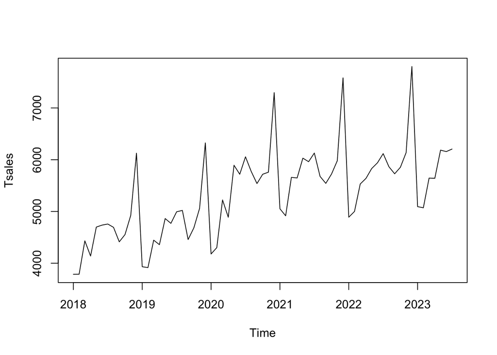

```r
library(forecast)

#Converting data into TimeSeries:

Tsales <- ts(MyDf$Sales, start = c(2018,1), end = c(2023,7), frequency = 12)

plot(Tsales)
```

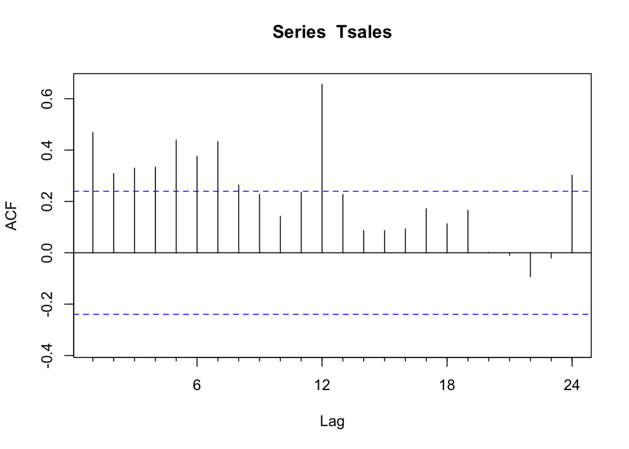

```r
Acf(Tsales)
```

## To check if Time series is stationary.

#### ADF test says differences is required if p-value is > 0.05. This means we need to try differencing the time series to achieve stationarity.

```r
adf.test(Tsales)
```

```
##
##  Augmented Dickey-Fuller Test
##
## data:  Tsales
## Dickey-Fuller = -3.0701, Lag order = 4, p-value = 0.1407
## alternative hypothesis: stationary
```

### Since this Time series is seasonal, we will use function nsdiffs.

#### NSDIFFS = 1 means differencing the series by subtracting each observation from the corresponding observation in the previous year.

```r
nsdiffs(Tsales)
```

```
## [1] 1
```

```r
ndiffs(Tsales) #For non-seasonal data()
```

```
## [1] 1
```

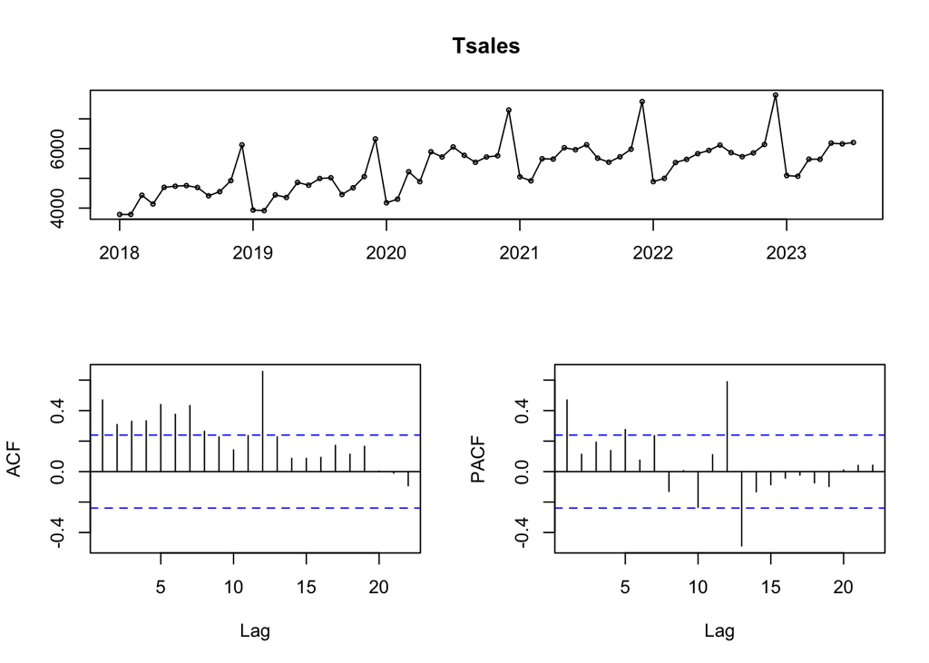

```r
# tsdisplay plots ACF,PACF and timeseries plot together.

tsdisplay(Tsales)
```

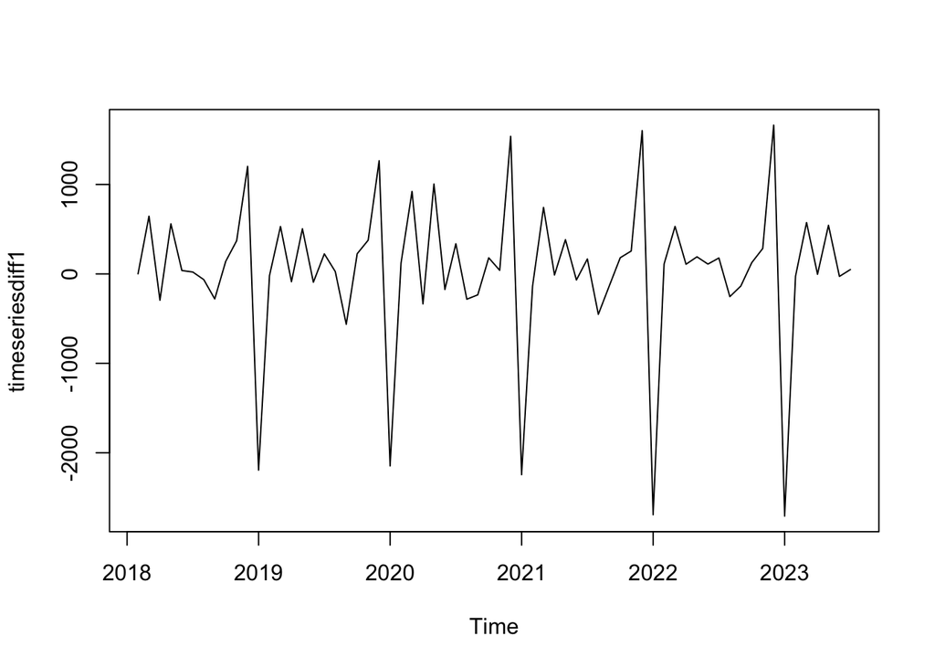

```r
timeseriesdiff1 <- diff(Tsales, differences=1)
plot(timeseriesdiff1)
```

### To check if more difference is needed:

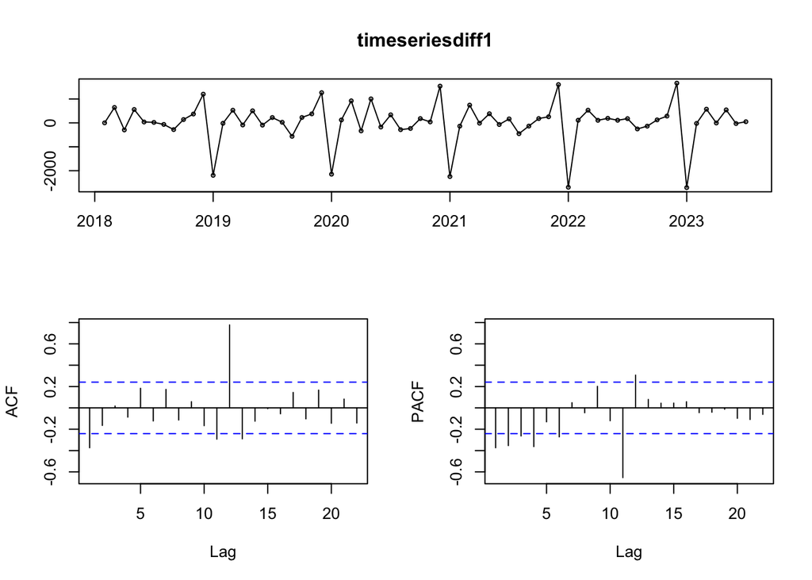

```r
tsdisplay(timeseriesdiff1)
```

### Using Auto-Arima Model and plotting it.

```r
auto_fit <- auto.arima(Tsales, trace=TRUE, stepwise = FALSE)
```

```
##
##  ARIMA(0,1,0)(0,1,0)[12]                    : 734.9153
##  ARIMA(0,1,0)(0,1,1)[12]                    : 730.4927
##  ARIMA(0,1,0)(1,1,0)[12]                    : 733.0045
##  ARIMA(0,1,0)(1,1,1)[12]                    : Inf
##  ARIMA(0,1,1)(0,1,0)[12]                    : 726.5086
##  ARIMA(0,1,1)(0,1,1)[12]                    : 720.4862
##  ARIMA(0,1,1)(1,1,0)[12]                    : 723.6249
##  ARIMA(0,1,1)(1,1,1)[12]                    : Inf
##  ARIMA(0,1,2)(0,1,0)[12]                    : 722.4257
##  ARIMA(0,1,2)(0,1,1)[12]                    : 717.4032
##  ARIMA(0,1,2)(1,1,0)[12]                    : 719.8456
##  ARIMA(0,1,2)(1,1,1)[12]                    : Inf
##  ARIMA(0,1,3)(0,1,0)[12]                    : 723.2523
##  ARIMA(0,1,3)(0,1,1)[12]                    : 719.7797
##  ARIMA(0,1,3)(1,1,0)[12]                    : 722.0724
##  ARIMA(0,1,3)(1,1,1)[12]                    : Inf
##  ARIMA(0,1,4)(0,1,0)[12]                    : 725.4743
##  ARIMA(0,1,4)(0,1,1)[12]                    : 721.9685
##  ARIMA(0,1,4)(1,1,0)[12]                    : 724.3358
##  ARIMA(0,1,5)(0,1,0)[12]                    : 727.2991
##  ARIMA(1,1,0)(0,1,0)[12]                    : 724.3524
##  ARIMA(1,1,0)(0,1,1)[12]                    : 717.571
##  ARIMA(1,1,0)(1,1,0)[12]                    : 720.455
##  ARIMA(1,1,0)(1,1,1)[12]                    : Inf
##  ARIMA(1,1,1)(0,1,0)[12]                    : 726.3767
##  ARIMA(1,1,1)(0,1,1)[12]                    : 719.6984
##  ARIMA(1,1,1)(1,1,0)[12]                    : 722.7033
##  ARIMA(1,1,1)(1,1,1)[12]                    : Inf
##  ARIMA(1,1,2)(0,1,0)[12]                    : 723.792
##  ARIMA(1,1,2)(0,1,1)[12]                    : 719.8008
##  ARIMA(1,1,2)(1,1,0)[12]                    : 722.1481
##  ARIMA(1,1,2)(1,1,1)[12]                    : Inf
##  ARIMA(1,1,3)(0,1,0)[12]                    : 725.6022
##  ARIMA(1,1,3)(0,1,1)[12]                    : 722.2268
##  ARIMA(1,1,3)(1,1,0)[12]                    : Inf
##  ARIMA(1,1,4)(0,1,0)[12]                    : Inf
##  ARIMA(2,1,0)(0,1,0)[12]                    : 726.2194
##  ARIMA(2,1,0)(0,1,1)[12]                    : 719.5654
##  ARIMA(2,1,0)(1,1,0)[12]                    : 722.6463
```

[output cut: 11 more lines]

```
##  ARIMA(3,1,0)(1,1,0)[12]                    : 723.8384
##  ARIMA(3,1,0)(1,1,1)[12]                    : Inf
##  ARIMA(3,1,1)(0,1,0)[12]                    : 728.5091
##  ARIMA(3,1,1)(0,1,1)[12]                    : 722.9584
##  ARIMA(3,1,1)(1,1,0)[12]                    : 725.8236
##  ARIMA(3,1,2)(0,1,0)[12]                    : 727.609
##  ARIMA(4,1,0)(0,1,0)[12]                    : 725.9306
##  ARIMA(4,1,0)(0,1,1)[12]                    : 722.3361
##  ARIMA(4,1,0)(1,1,0)[12]                    : 724.897
##  ARIMA(4,1,1)(0,1,0)[12]                    : 728.4637
##  ARIMA(5,1,0)(0,1,0)[12]                    : 728.4573
##
##
##
##  Best model: ARIMA(0,1,2)(0,1,1)[12]
```

```r
auto_fit
```

```
## Series: Tsales
## ARIMA(0,1,2)(0,1,1)[12]
##
## Coefficients:
##           ma1     ma2     sma1
##       -0.5549  0.3637  -0.4650
## s.e.   0.1270  0.1457   0.1757
##
## sigma^2 = 29106:  log likelihood = -354.29
## AIC=716.59   AICc=717.4   BIC=724.54
```

```r
attributes(auto_fit)
```

```
## $names
##  [1] "coef"      "sigma2"    "var.coef"  "mask"      "loglik"    "aic"
##  [7] "arma"      "residuals" "call"      "series"    "code"      "n.cond"
## [13] "nobs"      "model"     "bic"       "aicc"      "x"         "fitted"
##
## $class
## [1] "forecast_ARIMA" "ARIMA"          "Arima"
```

#### Best model: ARIMA(0,1,2)(0,1,1)[12]

##### Explanation: The notation “ARIMA(0,1,2)(0,1,1)[12]” represents a specific type of time series forecasting model in the context of ARIMA (AutoRegressive Integrated Moving Average) models with seasonality. Let’s break down each component:

##### ARIMA(p, d, q):

###### p: Order of the autoregressive (AR) component.

###### d: Degree of differencing (non-seasonal).

###### q: Order of the moving average (MA) component.

###### In the notation “ARIMA(0,1,2)”, it means there is no autoregressive component (p=0), first-order differencing is applied (d=1), and there are two lagged moving average terms (q=2). This implies that the model includes two lagged values of the differenced series in the moving average part.

##### Seasonal Component (SARIMA):

###### (P, D, Q)[s]: Seasonal order components.

###### P: Seasonal autoregressive order.

###### D: Seasonal degree of differencing.

###### Q: Seasonal moving average order.

###### s: Seasonal period (e.g., 12 for monthly data).

###### In the notation “(0,1,1)[12]”, it means there is no seasonal autoregressive component (P=0), first-order seasonal differencing is applied (D=1), one lagged value of the seasonally differenced series is included in the seasonal moving average part (Q=1), and the seasonal period is 12 (indicating monthly data).

##### Putting it all together, “ARIMA(0,1,2)(0,1,1)[12]” represents a seasonal ARIMA model where first-order differencing is applied both non-seasonally and seasonally, and the model includes lagged moving average terms in both the non-seasonal and seasonal components.

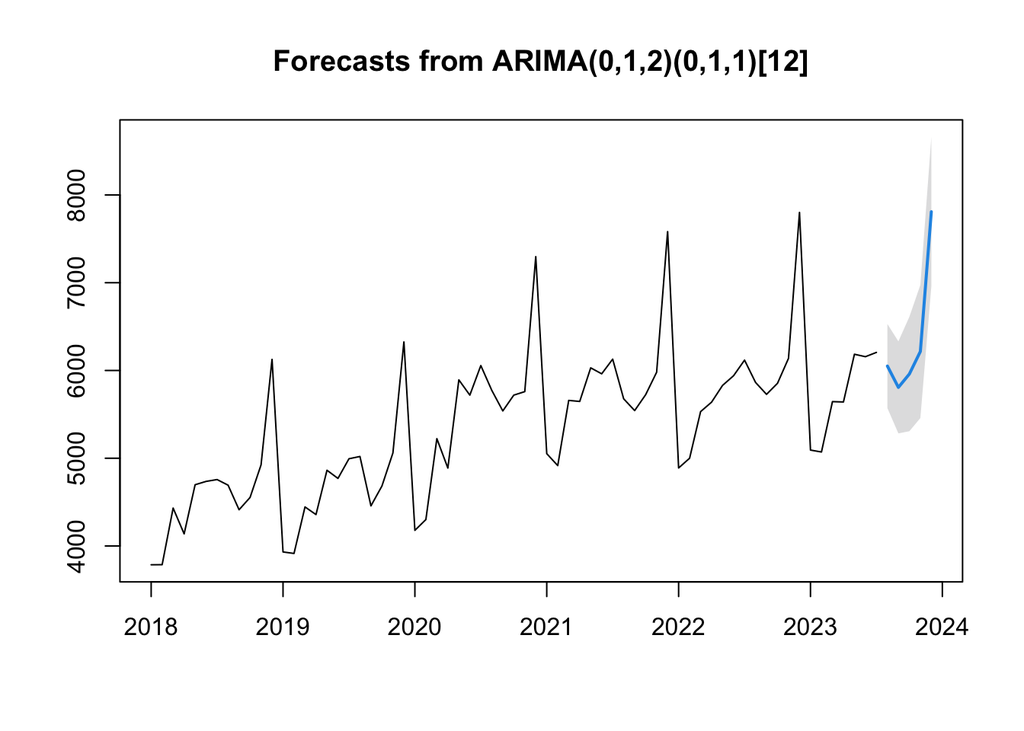

```r
F_Arima<-forecast(auto_fit,h=5,level=c(99.5))

plot(F_Arima)
```

### Residual Analysis

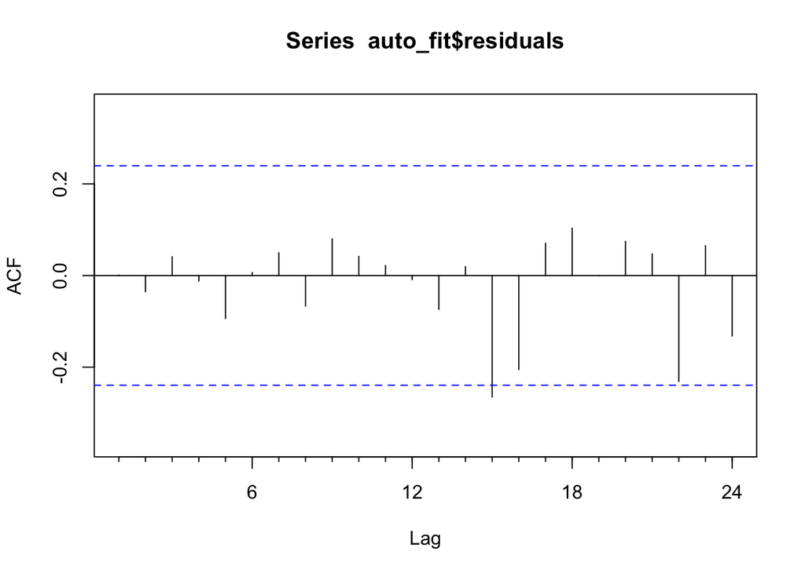

```r
Acf(auto_fit$residuals)
```

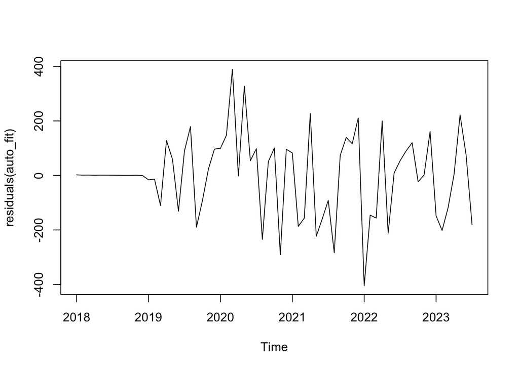

```r
plot.ts(residuals(auto_fit))
```

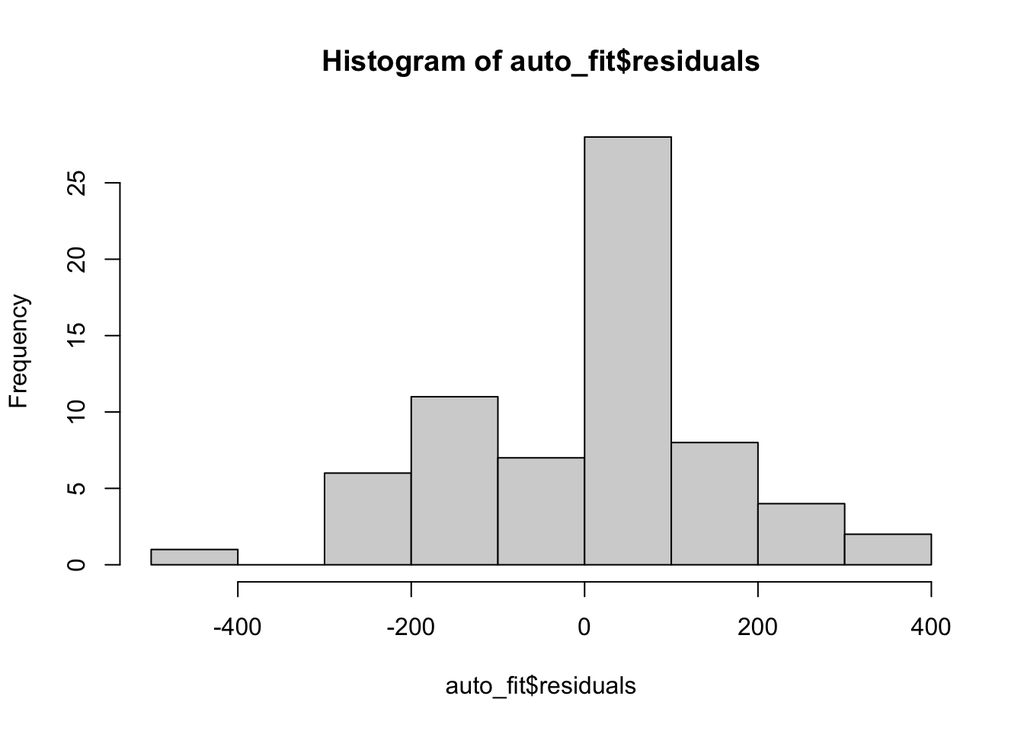

```r
hist(auto_fit$residuals)
```

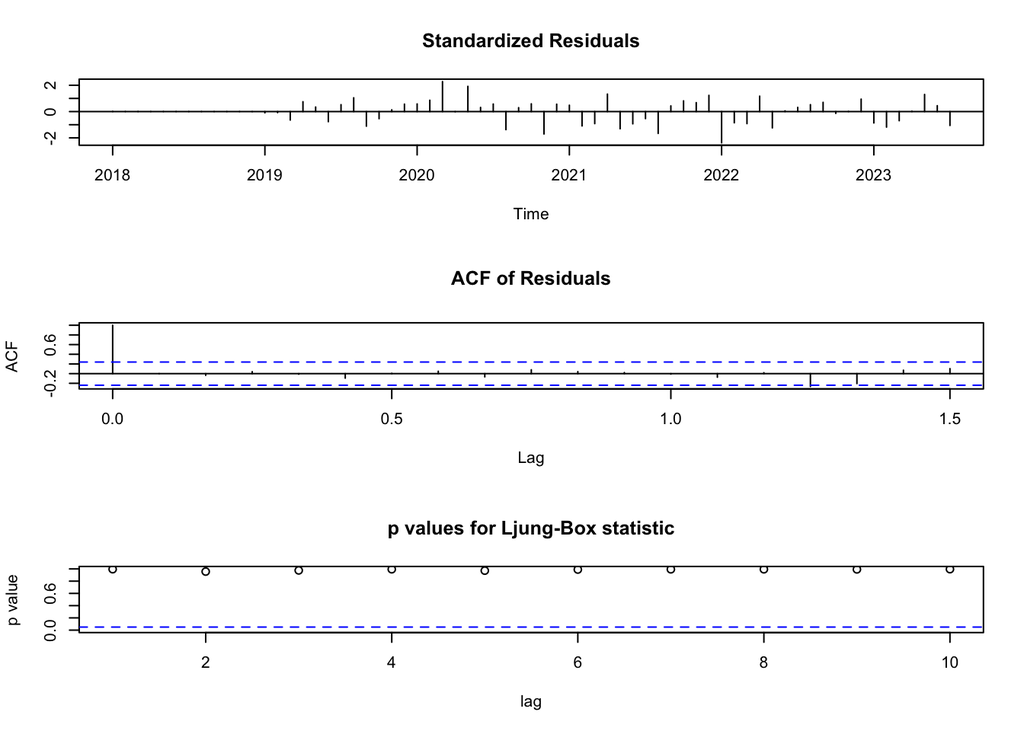

```r
tsdiag(auto_fit)
```

### Accuracy For ARIMA model

##### MAPE is approximately 2.0483%, providing a percentage measure of accuracy.

```r
accuracy(F_Arima)
```

```
##                      ME     RMSE      MAE         MPE     MAPE      MASE
## Training set -0.5534784 148.8467 112.1064 -0.06450998 2.048325 0.3504121
##                      ACF1
## Training set 0.0006912471
```